# Assignment Weeks 3 and 4

Leonard C. Steg

3/16/2022

# Preparation

### Load libraries, set wd and load AnnotationHub

```r
suppressPackageStartupMessages({
  library(AnnotationHub)
  library(Rsubread)
  library(rtracklayer)
  library(Biostrings)
  library(Rfastp)
  library(epiwraps)
})
setwd("/mnt/groupMansuy/leo/epibioinfo/week03/")
ah <- AnnotationHub()
```

```
## snapshotDate(): 2021-10-20
```

### Downloading raw reads

```r
if (!dir.exists("raw")){
dir.create("raw")
}

download.file("https://www.encodeproject.org/files/ENCFF001LJN/@@download/ENCFF001LJN.fastq.gz", dest="raw/mESCs.p300.fastq.gz")
```

# QC and trimming

## Using Rfastp

```r
dir.create("rfastp.trimmed")
if (!dir.exists("rfastp.trimmed")){
dir.create("rfastp.trimmed")
}
qc <- Rfastp::rfastp("raw/mESCs.p300.fastq.gz", outputFastq="rfastp.trimmed/mESC.p300",
                     maxNfilter=0, thread=4, overrepresentationAnalysis=TRUE)
```

### Plot Curve plots before and after QC

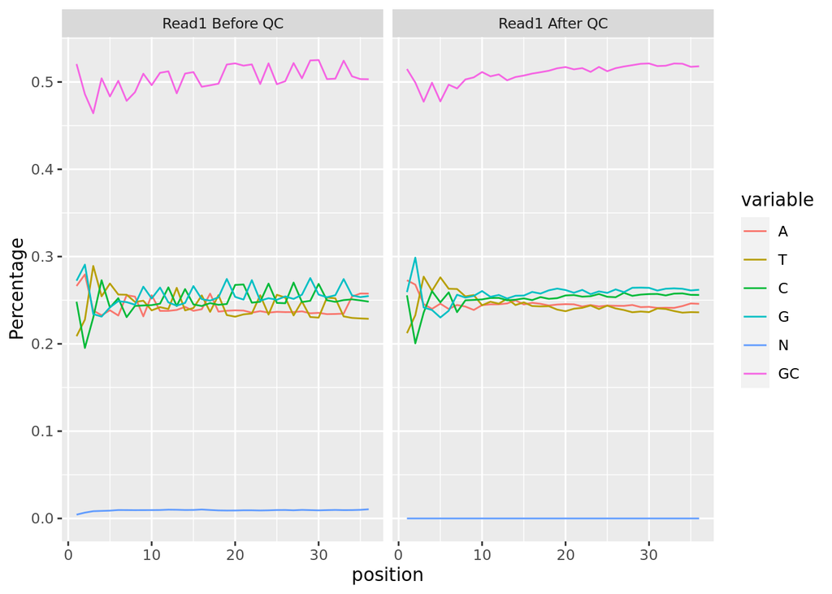

```r
Rfastp::curvePlot(qc, curve="content_curves")
```

# Alignment

```r
# Load the mouse genome sequence
genome <- ah[["AH49775"]]

# Export the genome sequence in fasta format
if (!dir.exists("mm_genome")){
dir.create("mm_genome")
}
export(import.2bit(genome), "mm_genome/genome.fasta.gz", compress=TRUE)
```

### Building the index using Bowtie2

```bash
bowtie2-build --threads 4 /mnt/groupMansuy/week03/mm_genome/genome.fasta.gz /mnt/groupMansuy/week03/mm_genome/bowtie2
```

### Alignment using samtools

```bash
mkdir -p aligned
(bowtie2 -p 4 -x mm_genome/bowtie2 -U rfastp.trimmed/mESC.p300_R1.fastq.gz) 2> aligned/mESC.p300.bowtie2 |\
  samtools view -bS - | samtools sort -@4 -m 2G - > aligned/mESC.p300.bam
samtools index aligned/mESC.p300.bam
```

```r
read.delim("aligned/mESC.p300.bowtie2")
```

```
##                      X17184393.reads..of.these.
## 1   17184393 (100.00%) were unpaired; of these:
## 2              3802198 (22.13%) aligned 0 times
## 3       9822428 (57.16%) aligned exactly 1 time
## 4             3559767 (20.72%) aligned >1 times
## 5                 77.87% overall alignment rate
```

# Peak calling

### Using MACS2

```bash
mkdir -p peaks
macs2 callpeak --outdir peaks -n mESC.p300 --gsize mm -t aligned/mESC.p300.bam
```

### Importing peaks into R

```r
peaks <- rtracklayer::import("peaks/mESC.p300_peaks.narrowPeak", format = "narrowPeak")
```

### Assignment question: How many peaks do we find?

```r
length(peaks)
```

```
## [1] 6394
```

# Generating coverage tracks

```r
dir.create("tracks")
if (!dir.exists("tracks")){
dir.create("tracks")
}
bam2bw("aligned/mESC.p300.bam", "tracks/mESC.p300.bw", binWidth=10, extend=50, scaling=TRUE)
```

# Load Mouse EnsDb to have gene annoation

```r
ensdb <- ah[["AH89211"]] # Mouse EnsDb
```

```
## loading from cache
```

```
## require("ensembldb")
```

# Looking at the p300 peak(s) around the Sox9 gene

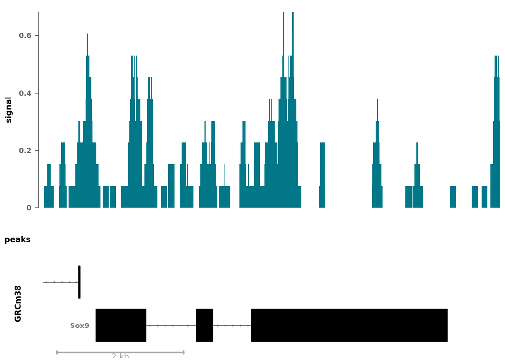

```r
plotSignalTracks(list(signal="tracks/mESC.p300.bw", peaks=peaks), region="Sox9", ensdb=ensdb, colors = "#017788", transcripts = "collapsed")
```

### Add gene annotaiton to peak data and describe annotation of identified genes

```r
peakAnno <- annotateRegions(peaks, ensdb)
table(peakAnno$class)
```

```
##
##                  exonic              intergenic                intronic
##                     168                    2388                    1731
##       proximal <=1000bp proximal >1000&<=2500bp                     TSS
##                    1024                     710                     312
```

```r
topPeaks <- peaks[peaks$pValue  > sort(peaks$pValue, decreasing = T)[1000]]
length(topPeaks)
```

```
## [1] 963
```

```r
peakSignals <- signal2Matrix("tracks/mESC.p300.bw", regions = topPeaks, extend = 2000, w = 20)
```

```
## Reading tracks/mESC.p300.bw
```

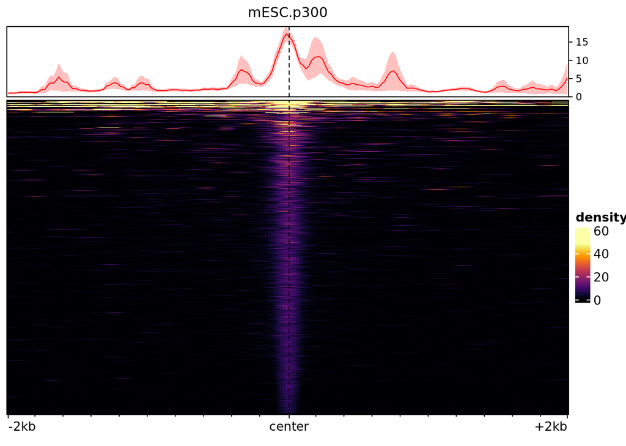

```r
plotEnrichedHeatmaps(peakSignals)
```

# Compare p300 peaks with Histone modification peaks (from public datasets)

### Download peak data from H3K4me3, H3K4me1, H3K27ac, and H3K27me3 ChIP datasets (Mus musculus strain Bruce4 ES-Bruce4)

```r
download.file(url = "https://www.encodeproject.org/files/ENCFF671UNN/@@download/ENCFF671UNN.bed.gz", dest="/mnt/groupMansuy/leo/epibioinfo/week04/EncodePeaks/H3K4me3.bed.gz")
download.file(url = "https://www.encodeproject.org/files/ENCFF333IJH/@@download/ENCFF333IJH.bed.gz", dest="/mnt/groupMansuy/leo/epibioinfo/week04/EncodePeaks/H3K4me1.bed.gz")
download.file(url = "https://www.encodeproject.org/files/ENCFF274UIB/@@download/ENCFF274UIB.bed.gz", dest="/mnt/groupMansuy/leo/epibioinfo/week04/EncodePeaks/H3K27ac.bed.gz")
download.file(url = "https://www.encodeproject.org/files/ENCFF558YNC/@@download/ENCFF558YNC.bed.gz", dest="/mnt/groupMansuy/leo/epibioinfo/week04/EncodePeaks/H3K27me3.bed.gz")
```

### Load in H3K4me3 data, adjust the seqlevels (to have the same chromosome names for both datasets) and print the proportion of the p300 peaks that overlap with H3K4me3

```r
h3k4me3 <- rtracklayer::import("/mnt/groupMansuy/leo/epibioinfo/week04/EncodePeaks/H3K4me3.bed.gz", format = "narrowPeak")
h3k4me3 <- renameSeqlevels(x = h3k4me3, levels(gsub("chr", "", seqnames(h3k4me3))))

p300h3k4me3 <- overlapsAny(peaks, h3k4me3)
sum(p300h3k4me3)/length(p300h3k4me3)
```

```
## [1] 0.2876134
```

### Load in H3K4me1 data, adjust the seqlevels and print the proportion of the p300 peaks that overlap with H3K4me1

```r
h3k4me1 <- rtracklayer::import("/mnt/groupMansuy/leo/epibioinfo/week04/EncodePeaks/H3K4me1.bed.gz", format = "narrowPeak")
h3k4me1 <- renameSeqlevels(x = h3k4me1, levels(gsub("chr", "", seqnames(h3k4me1))))

p300h3k4me1 <- overlapsAny(peaks, h3k4me1)
sum(p300h3k4me1)/length(p300h3k4me1)
```

```
## [1] 0.1515483
```

### Load in H3K27ac data, adjust the seqlevels and print the proportion of the p300 peaks that overlap with H3K27ac

```r
h3k27ac <- rtracklayer::import("/mnt/groupMansuy/leo/epibioinfo/week04/EncodePeaks/H3K27ac.bed.gz", format = "narrowPeak")
h3k27ac <- renameSeqlevels(x = h3k27ac, levels(gsub("chr", "", seqnames(h3k27ac))))

p300h3k27ac <- overlapsAny(peaks, h3k27ac)
sum(p300h3k27ac)/length(p300h3k27ac)
```

```
## [1] 0.546919
```

### Load in H3K27me3 data, adjust the seqlevels and print the proportion of the p300 peaks that overlap with H3K27me3

```r
h3k27me3 <- rtracklayer::import("/mnt/groupMansuy/leo/epibioinfo/week04/EncodePeaks/H3K27me3.bed.gz", format = "narrowPeak")
h3k27me3 <- renameSeqlevels(x = h3k27me3, levels(gsub("chr", "", seqnames(h3k27me3))))

p300h3k27me3 <- overlapsAny(peaks, h3k27me3)
sum(p300h3k27me3)/length(p300h3k27me3)
```

```
## [1] 0.005317485
```